# Module 2, Lesson 2a: Digging into SLR

Here is the linear regression model that we fit previously, regressing systolic blood pressure (`systolic`) against the person’s age (`age`) and using the `lm` function to do so:

```r
library(healthds)
library(tidyverse)
BPUrban300 %>%
  lm(formula = systolic ~ age)
```

```
##
## Call:
## lm(formula = systolic ~ age, data = .)
##
## Coefficients:
## (Intercept)          age
##     93.8760       0.5371
```

You will notice that we are now using the pipe operator, which we learned about in Course 1. Specifically, we are piping in the `BPUrban300` dataset into `lm`. However, in order to do so correctly, we must explicitly match the formula argument, i.e. `formula = systolic ~ age`, so that `lm` knows we want to match `BPUrban300` with its *second* argument (`data`) and not its first argument (`formula`).

Now let us re-create the scatterplot comparing systolic blood pressure to age in these data:

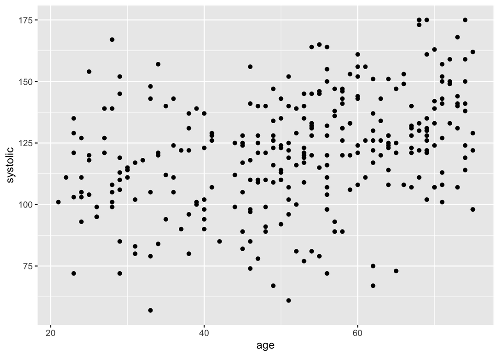

```r
age_systolic_plot <-
  ggplot(BPUrban300) +
  geom_point(aes(age, systolic))
age_systolic_plot
```

Note that the first three lines above create the ggplot object (which will allow us to modify and augment it below), and the last line renders the plot.

Now let us augment this scatterplot with the fitted linear regression line. To do so, we layer – or add – on a new geom, `geom_abline`:

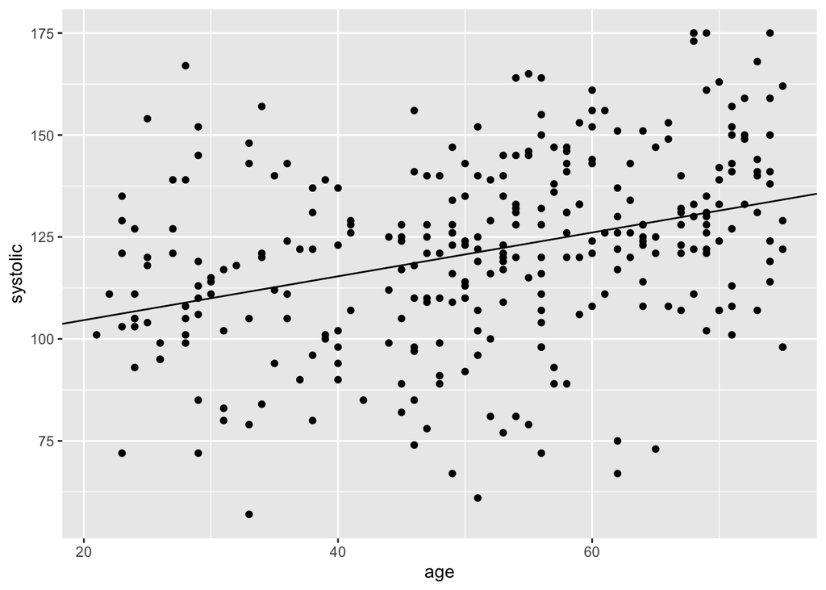

```r
age_systolic_plot +
  geom_abline(slope = 0.537, intercept = 93.876)
```

The two most important arguments of `geom_abline` are *not* aesthetics that are mapped to a variable, meaning that they do not appear inside of a call to `aes()`. These two argument names are `slope` and `intercept` arguments, and for some of you this will take you back to your days of high school algebra. When we call `geom_abline`, we are plotting the line $y = ax + b$, where $a$ is the value of the `slope` argument and $b$ is the value of the `intercept` argument. In the code above, we’ve provided the values from the fitted regression line.

One natural risk from linear regressions – and statistical modeling generally – is that of extrapolation. If we extend the limits of the x-axis from 1 year to 99 years using the `scale_x_continuous` function, we see the following:

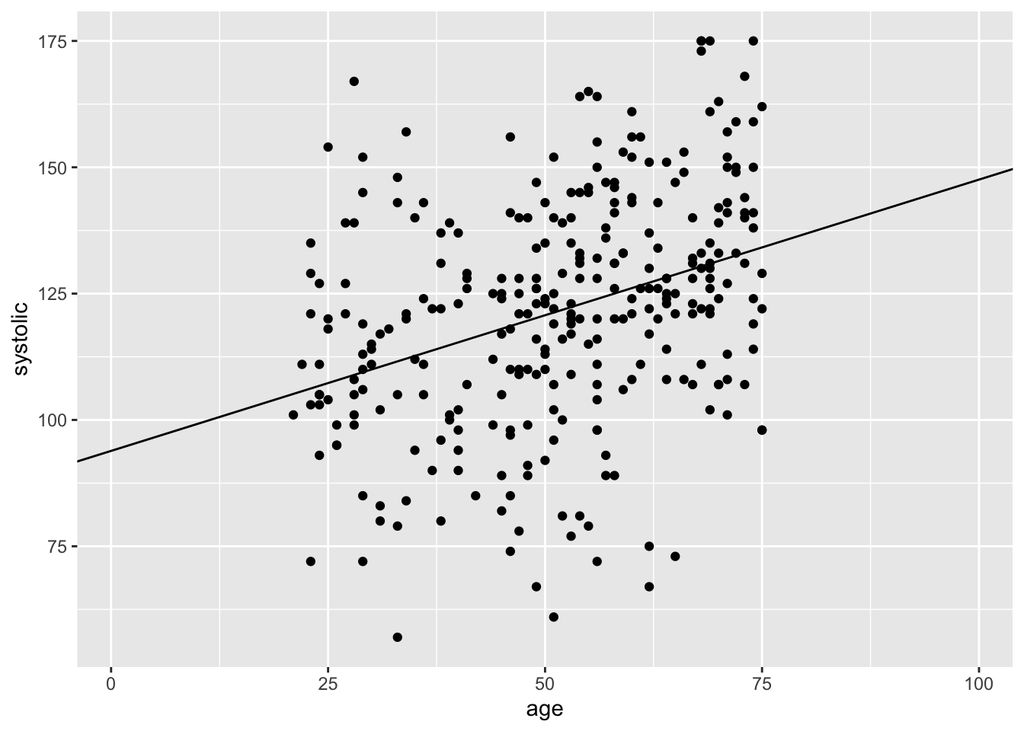

```r
age_systolic_plot +
  geom_abline(slope = 0.537, intercept = 93.876) +
  scale_x_continuous(limits = c(1, 99))
```

We see from this that our linear regression estimates that the systolic blood pressure for a one-year old is about 94.5 (which, by the way, you could mathematically determine by taking the intercept, 93.9, and adding to it one value of the slope, 0.54, since this slope represents the per-year increase in estimated systolic blood pressure). Alternatively, our model estimates that the systolic blood pressure a 99-year old is about 147. In this case, these are not ridiculous estimates, but the more important lesson here is that the youngest persons in our data are in their early 20s, and the oldest persons are 75. We have no data to support the notion that this line can be used to estimate the blood pressure of very young or very old persons. Even more foolish that our model will happily estimate something that is biologically impossible, say, the blood pressure of someone who is -2 (negative 2) years old.

### Centering variables

We now make use of another Course 1 idea, that of defining new variables in our data with the `mutate` function. Specifically, we create a variable called `age_centered`, which is defined as each person’s age minus the overall average age of the persons in our dataset. The average value of this new variable will be zero, and so the “_centered” descriptor means ‘centered around zero’.

Creating this centered age and regressing upon *it* instead of age, we get the following:

```r
BPUrban300 %>%
  mutate(age_centered = age - mean(age)) %>%
  lm(formula = systolic ~ age_centered)
```

```
##
## Call:
## lm(formula = systolic ~ age_centered, data = .)
##
## Coefficients:
##  (Intercept)  age_centered
##     121.5933        0.5371
```

Relative to our first regression model, one estimated parameter has stayed the same and one estimated parameter has changed. The one that has stayed the same is the slope parameter: we still estimate that systolic blood pressure changes by about 0.537 units for each year that a person is older. The one that has changed is the intercept parameter, which now takes on value 121.593.

Why has the intercept changed value when we regress on centered age? Because its interpretation has also changed. In the first model, the intercept is the expected systolic blood pressure for a person who is zero years old (remember – this is a mathematically accurate statement even though our data do not support such an extrapolation); in the second model, the intercept is the expected systolic blood pressure for a person whose *centered* age is zero, or, equivalently, a person whose age is equal to the overall mean age. In these data, the mean age is 51.6 years:

```r
BPUrban300 %>% summarize(mean(age))
```

```
##   mean(age)
## 1  51.60333
```

To be clear, these models are giving the **same** conclusions. To see this, let us use the first model to estimate the systolic blood pressure of someone who is 51.6 years old: we take the estimated intercept, 93.876, and add to it 51.6*0.537, or 27.709, which yields 121.59. We have lost some digits of precision due to rounding, but apart from that this is exactly the intercept value from our second model.

### Statistical inference with linear regression

Generally speaking, the *sample* (sometimes called ‘estimated’) associations from a linear regression will never be equal to zero, even when we have data arising from a *population* in which the association is zero. This is because of sampling variability. Thus, we usually do not stop at fitting the regression and interpreting the associations, as we’ve done above. Rather, we ask statistical questions about how consistent our estimated associations are with a scenario in which no association exists in truth. For that, we need to quantify the uncertainty our data have about these estimated associations. If the uncertainty is small, then we have more confidence in our estimated association.

To do this in R, we use the `summary` function. Note, that this is different than the `summarize` function, which we used above and discussed in detail in Course 1. `summarize` is part of the `tidyverse` set of packages and useful for looking at summary statistics in tibbles; `summary` is a helper function for “unpacking” fitted regression models, such as quantifying uncertainty.

Here is the simplest use of `summary`:

```r
BPUrban300 %>%
  lm(formula = systolic ~ age) %>%
  summary()
```

```
##
## Call:
## lm(formula = systolic ~ age, data = .)
##
## Residuals:
##     Min      1Q  Median      3Q     Max
## -60.269 -12.870  -0.095  13.921  58.085
##
## Coefficients:
##             Estimate Std. Error t value Pr(>|t|)
## (Intercept) 93.87599    4.52144   20.76  < 2e-16 ***
## age          0.53712    0.08419    6.38 6.75e-10 ***
## ---
## Signif. codes:  0 '***' 0.001 '**' 0.01 '*' 0.05 '.' 0.1 ' ' 1
##
## Residual standard error: 21.7 on 298 degrees of freedom
## Multiple R-squared:  0.1202, Adjusted R-squared:  0.1172
## F-statistic:  40.7 on 1 and 298 DF,  p-value: 6.754e-10
```

We see point estimates of the intercept and slope parameters. We also see estimates of the standard error, `Std. Error`, which quantifies the uncertainty about each of the point estimates. Larger standard errors correspond to more uncertainty. In the next column over, we have a column called `t value`, which are the test statistics. Remember that test statistics have a certain theoretical distribution under a null hypothesis – in this case that null hypothesis is that the true value of the parameter is 0. The last column, `Pr(>|t|)`, gives us the the p-values: the probability of observing the test statistics (or one even larger in magnitude) under the null hypothesis.

Consider the two p-values we see in the table above. The first, corresponding to the intercept parameter, is `<2e-16`, which is R’s way of writing $<2\times10^{-16}$ or, equivalently, $<0.0000000000000002$. This is incredibly small and means that the t-statistic is extremely unlikely to have arisen from a distribution with a mean of zero. Perhaps more helpfully, we would consequently infer that we have strong evidence to suggest that the *true* intercept parameter, which we’ve *estimated* to be 93.9, is not equal to 0. Translating this to the context of the problem, we have strong evidence to suggest that, for someone who is zero years old, the mean systolic blood pressure is not equal to zero. This answers a question that no one is asking and is why Dr. Mukherjee said that inference on the intercept parameter is not usually of interest.

More interesting is the other p-value: `6.75e-10` or $6.75\times 10^{-10}$. This is also incredibly small. Following the same logic as before, we would conclude that there is strong evidence to suggest that the change in the mean systolic blood pressure as the age of the person increases is not equal to zero. This is presumably a more interesting question to be answered.

Just above the Coefficients table, we see information about the model’s residuals. Recall that the residual is the difference between the person’s actual systolic blood pressure and their predicted systolic blood pressure according to our model. Any fitted linear model minimizes the sum of the *squared* residuals – here we see a summary of the residuals themselves: the smallest residual, the three middle quartiles, and the largest residual. We can use these to get a sense of the unexplained variability in our model. For example, the first and the third quartiles are -12.9 and 13.9, respectively, meaning that for half of our sample, the discrepancy between the actual systolic blood pressure and predicted systolic blood pressure is less than -12.9 points or greater than 13.9 points. Thus, we arrive at a perhaps counterintuitive conclusion that, despite the highly significant association between the two variables, age alone is not good at predicting blood pressure.

In additional to calculating standard errors and p-values, we are also often interested in obtaining confidence intervals for parameters of interest. To do so, we use the `confint` function in R:

```r
BPUrban300 %>%
  lm(formula = systolic ~ age) %>%
  confint()
```

```
##                  2.5 %      97.5 %
## (Intercept) 84.9779848 102.7739978
## age          0.3714423   0.7028039
```

This function calculates 95% confidence intervals for all of the parameters in a regression. Just like p-values, the formal interpretation of a confidence interval requires thinking about repeating the experiment multiple times: if we were to conduct a large number of identical but independent studies in this population, then 95% of the confidence intervals that we generate would cover the true population parameter. In real analyses we do not (and cannot) know whether our one interval has covered the true parameter or not. Informally, confidence intervals quantify uncertainty that we have about our parameter estimate: wider intervals correspond to greater uncertainty and narrower intervals correspond to less uncertainty.

For the parameter corresponding to age, the lower bound of the interval is 0.371, and the upper bound of the interval is 0.702. Given how far away from zero the lower bound of this confidence interval is, we have a great deal of certainty that the true association between age and systolic blood pressure is greater than 0. Note that this inference leads us to the same conclusion as an inference based upon the p-value.